# IODS course project

# Chapter 4

install.packages(“rmarkdown”)

library(rmarkdown)

install.packages(c(“dplyr”,“MASS”))

```r
#2
##load dataset Boston from MASS package


library(dplyr)
library(MASS)
data <- MASS::Boston

## explore the structure and the dimensions of the dataset
str(data)
```

```
## 'data.frame':    506 obs. of  14 variables:
##  $ crim   : num  0.00632 0.02731 0.02729 0.03237 0.06905 ...
##  $ zn     : num  18 0 0 0 0 0 12.5 12.5 12.5 12.5 ...
##  $ indus  : num  2.31 7.07 7.07 2.18 2.18 2.18 7.87 7.87 7.87 7.87 ...
##  $ chas   : int  0 0 0 0 0 0 0 0 0 0 ...
##  $ nox    : num  0.538 0.469 0.469 0.458 0.458 0.458 0.524 0.524 0.524 0.524 ...
##  $ rm     : num  6.58 6.42 7.18 7 7.15 ...
##  $ age    : num  65.2 78.9 61.1 45.8 54.2 58.7 66.6 96.1 100 85.9 ...
##  $ dis    : num  4.09 4.97 4.97 6.06 6.06 ...
##  $ rad    : int  1 2 2 3 3 3 5 5 5 5 ...
##  $ tax    : num  296 242 242 222 222 222 311 311 311 311 ...
##  $ ptratio: num  15.3 17.8 17.8 18.7 18.7 18.7 15.2 15.2 15.2 15.2 ...
##  $ black  : num  397 397 393 395 397 ...
##  $ lstat  : num  4.98 9.14 4.03 2.94 5.33 ...
##  $ medv   : num  24 21.6 34.7 33.4 36.2 28.7 22.9 27.1 16.5 18.9 ...
```

```r
head(data)
```

```
##      crim zn indus chas   nox    rm  age    dis rad tax ptratio  black lstat
## 1 0.00632 18  2.31    0 0.538 6.575 65.2 4.0900   1 296    15.3 396.90  4.98
## 2 0.02731  0  7.07    0 0.469 6.421 78.9 4.9671   2 242    17.8 396.90  9.14
## 3 0.02729  0  7.07    0 0.469 7.185 61.1 4.9671   2 242    17.8 392.83  4.03
## 4 0.03237  0  2.18    0 0.458 6.998 45.8 6.0622   3 222    18.7 394.63  2.94
## 5 0.06905  0  2.18    0 0.458 7.147 54.2 6.0622   3 222    18.7 396.90  5.33
## 6 0.02985  0  2.18    0 0.458 6.430 58.7 6.0622   3 222    18.7 394.12  5.21
##   medv
## 1 24.0
## 2 21.6
## 3 34.7
## 4 33.4
## 5 36.2
## 6 28.7
```

The data consist of 506 observations of 14 variables.

install.packages(“ggplot2”)

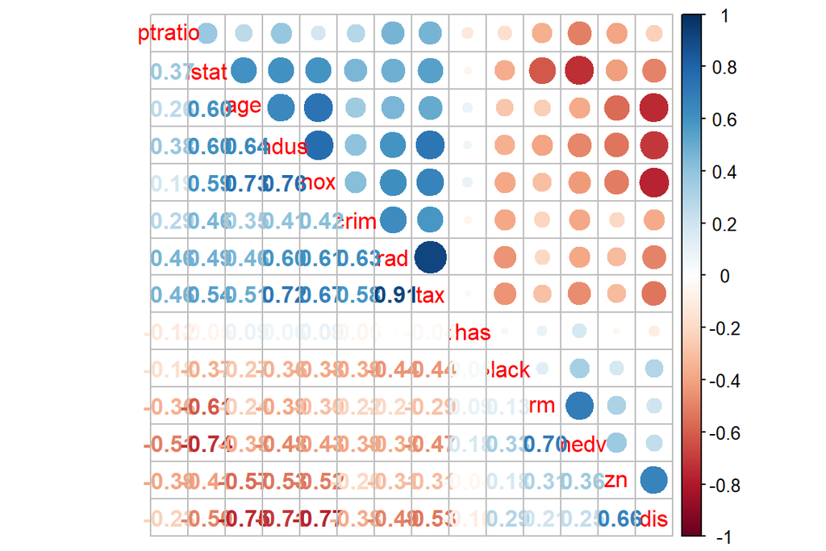

```r
#3

library(ggplot2)
library(corrplot)
##plot correlation plot
corrplot.mixed(cor(data, use = "pairwise"), order = "hclust")
```

```r
cor_matrix <- cor(data)
cor_matrix
```

```
##                crim          zn       indus         chas         nox
## crim     1.00000000 -0.20046922  0.40658341 -0.055891582  0.42097171
## zn      -0.20046922  1.00000000 -0.53382819 -0.042696719 -0.51660371
## indus    0.40658341 -0.53382819  1.00000000  0.062938027  0.76365145
## chas    -0.05589158 -0.04269672  0.06293803  1.000000000  0.09120281
## nox      0.42097171 -0.51660371  0.76365145  0.091202807  1.00000000
## rm      -0.21924670  0.31199059 -0.39167585  0.091251225 -0.30218819
## age      0.35273425 -0.56953734  0.64477851  0.086517774  0.73147010
## dis     -0.37967009  0.66440822 -0.70802699 -0.099175780 -0.76923011
## rad      0.62550515 -0.31194783  0.59512927 -0.007368241  0.61144056
## tax      0.58276431 -0.31456332  0.72076018 -0.035586518  0.66802320
## ptratio  0.28994558 -0.39167855  0.38324756 -0.121515174  0.18893268
## black   -0.38506394  0.17552032 -0.35697654  0.048788485 -0.38005064
## lstat    0.45562148 -0.41299457  0.60379972 -0.053929298  0.59087892
## medv    -0.38830461  0.36044534 -0.48372516  0.175260177 -0.42732077
##                  rm         age         dis          rad         tax    ptratio
## crim    -0.21924670  0.35273425 -0.37967009  0.625505145  0.58276431  0.2899456
## zn       0.31199059 -0.56953734  0.66440822 -0.311947826 -0.31456332 -0.3916785
## indus   -0.39167585  0.64477851 -0.70802699  0.595129275  0.72076018  0.3832476
## chas     0.09125123  0.08651777 -0.09917578 -0.007368241 -0.03558652 -0.1215152
## nox     -0.30218819  0.73147010 -0.76923011  0.611440563  0.66802320  0.1889327
## rm       1.00000000 -0.24026493  0.20524621 -0.209846668 -0.29204783 -0.3555015
## age     -0.24026493  1.00000000 -0.74788054  0.456022452  0.50645559  0.2615150
## dis      0.20524621 -0.74788054  1.00000000 -0.494587930 -0.53443158 -0.2324705
## rad     -0.20984667  0.45602245 -0.49458793  1.000000000  0.91022819  0.4647412
## tax     -0.29204783  0.50645559 -0.53443158  0.910228189  1.00000000  0.4608530
## ptratio -0.35550149  0.26151501 -0.23247054  0.464741179  0.46085304  1.0000000
## black    0.12806864 -0.27353398  0.29151167 -0.444412816 -0.44180801 -0.1773833
## lstat   -0.61380827  0.60233853 -0.49699583  0.488676335  0.54399341  0.3740443
## medv     0.69535995 -0.37695457  0.24992873 -0.381626231 -0.46853593 -0.5077867
##               black      lstat       medv
## crim    -0.38506394  0.4556215 -0.3883046
## zn       0.17552032 -0.4129946  0.3604453
## indus   -0.35697654  0.6037997 -0.4837252
## chas     0.04878848 -0.0539293  0.1752602
## nox     -0.38005064  0.5908789 -0.4273208
## rm       0.12806864 -0.6138083  0.6953599
## age     -0.27353398  0.6023385 -0.3769546
## dis      0.29151167 -0.4969958  0.2499287
## rad     -0.44441282  0.4886763 -0.3816262
## tax     -0.44180801  0.5439934 -0.4685359
## ptratio -0.17738330  0.3740443 -0.5077867
## black    1.00000000 -0.3660869  0.3334608
## lstat   -0.36608690  1.0000000 -0.7376627
## medv     0.33346082 -0.7376627  1.0000000
```

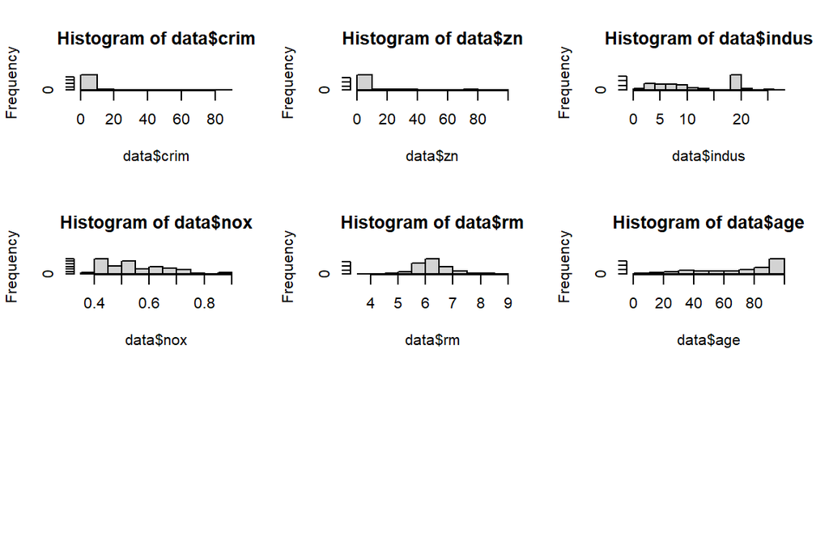

```r
## Graphical overview of the data

par(mfrow = c(3,3))
hist(data$crim)
hist(data$zn)
hist(data$indus)
hist(data$nox)
hist(data$rm)
hist(data$age)

par(mfrow = c(3,3))
```

[output not shown]

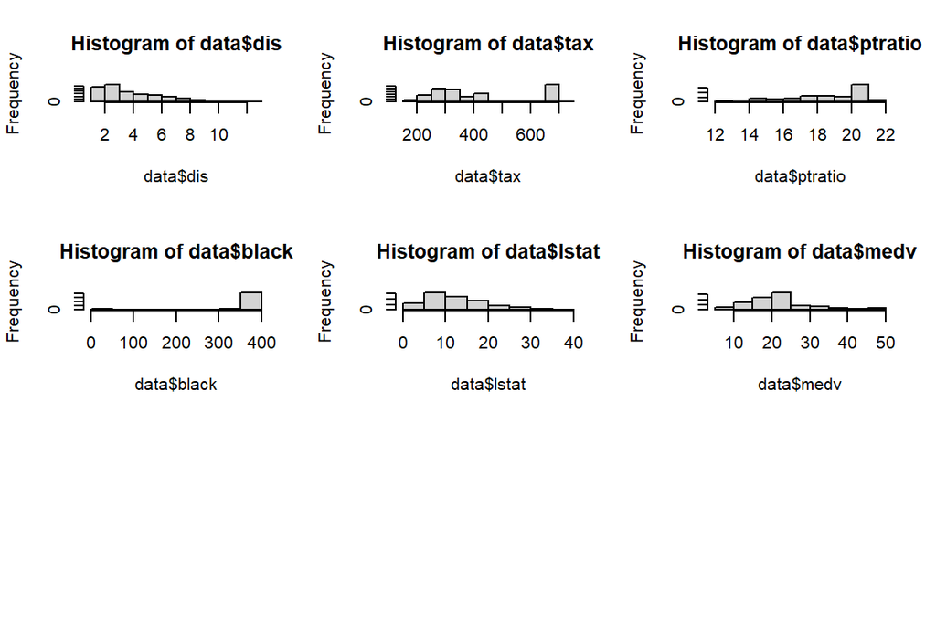

```r
hist(data$dis)
hist(data$tax)
hist(data$ptratio)
hist(data$black)
hist(data$lstat)
hist(data$medv)

##summary
summary(data)
```

[output not shown]

Except ‘rm’ for the average number of rooms per dwelling, all the numerical variables don’t look normally distributed.

We can observe strong correlations between the variables rad and tax (0.91), dis and age (0.75), dis and nox (0.77), indus and nox (0.76), nox and age (0.73), lstat and medv (0.74).

```r
#4

## center and standardize variables
data_scaled <- scale(data)

## print summaries of the scaled variables
summary(data_scaled) # note that now all means are 0 as supposed to
```

```
##       crim                 zn               indus              chas
##  Min.   :-0.419367   Min.   :-0.48724   Min.   :-1.5563   Min.   :-0.2723
##  1st Qu.:-0.410563   1st Qu.:-0.48724   1st Qu.:-0.8668   1st Qu.:-0.2723
##  Median :-0.390280   Median :-0.48724   Median :-0.2109   Median :-0.2723
##  Mean   : 0.000000   Mean   : 0.00000   Mean   : 0.0000   Mean   : 0.0000
##  3rd Qu.: 0.007389   3rd Qu.: 0.04872   3rd Qu.: 1.0150   3rd Qu.:-0.2723
##  Max.   : 9.924110   Max.   : 3.80047   Max.   : 2.4202   Max.   : 3.6648
##       nox                rm               age               dis
##  Min.   :-1.4644   Min.   :-3.8764   Min.   :-2.3331   Min.   :-1.2658
##  1st Qu.:-0.9121   1st Qu.:-0.5681   1st Qu.:-0.8366   1st Qu.:-0.8049
##  Median :-0.1441   Median :-0.1084   Median : 0.3171   Median :-0.2790
##  Mean   : 0.0000   Mean   : 0.0000   Mean   : 0.0000   Mean   : 0.0000
##  3rd Qu.: 0.5981   3rd Qu.: 0.4823   3rd Qu.: 0.9059   3rd Qu.: 0.6617
##  Max.   : 2.7296   Max.   : 3.5515   Max.   : 1.1164   Max.   : 3.9566
##       rad               tax             ptratio            black
##  Min.   :-0.9819   Min.   :-1.3127   Min.   :-2.7047   Min.   :-3.9033
##  1st Qu.:-0.6373   1st Qu.:-0.7668   1st Qu.:-0.4876   1st Qu.: 0.2049
##  Median :-0.5225   Median :-0.4642   Median : 0.2746   Median : 0.3808
##  Mean   : 0.0000   Mean   : 0.0000   Mean   : 0.0000   Mean   : 0.0000
##  3rd Qu.: 1.6596   3rd Qu.: 1.5294   3rd Qu.: 0.8058   3rd Qu.: 0.4332
##  Max.   : 1.6596   Max.   : 1.7964   Max.   : 1.6372   Max.   : 0.4406
##      lstat              medv
##  Min.   :-1.5296   Min.   :-1.9063
##  1st Qu.:-0.7986   1st Qu.:-0.5989
##  Median :-0.1811   Median :-0.1449
##  Mean   : 0.0000   Mean   : 0.0000
##  3rd Qu.: 0.6024   3rd Qu.: 0.2683
##  Max.   : 3.5453   Max.   : 2.9865
```

```r
## change the object to data frame
data_scaled_df <- as.data.frame(data_scaled)

## create a quantile vector of crim
bins <- quantile(data_scaled_df$crim)

# create a categorical variable 'crime'
crime <- cut(data_scaled_df$crim, breaks = bins, include.lowest = TRUE, label = c("low", "med_low", "med_high", "high"))

# remove original crim from the dataset
data_scaled_df <- dplyr::select(data_scaled_df, -crim)

# add the new categorical value to scaled data
data_scaled_df <- data.frame(data_scaled_df, crime)


# number of rows in the Boston dataset
n <- nrow(data_scaled_df)

# choose randomly 80% of the rows
ind <- sample(n,  size = n * 0.8)

# create train and test set
train <- data_scaled_df[ind,]
test <-data_scaled_df[-ind,]
```

All standardized values correspond to a mean = 0. and create a categorical variable “crime”. Let’s also divide the dataset to train and test sets, so that 80% of the data belongs to the train set.

```r
#5
## fit a linear discriminant analysis
lda.fit <- lda(crime ~ . , data = train)

lda.fit
```

```
## Call:
## lda(crime ~ ., data = train)
##
## Prior probabilities of groups:
##       low   med_low  med_high      high
## 0.2475248 0.2450495 0.2599010 0.2475248
##
## Group means:
##                  zn      indus        chas        nox         rm        age
## low       0.8395928 -0.8838873 -0.07547406 -0.8616333  0.4410590 -0.8610260
## med_low  -0.1537513 -0.2990409 -0.03371693 -0.5628463 -0.1552321 -0.3902827
## med_high -0.3794348  0.2543368  0.21512144  0.4060948  0.1212662  0.4919882
## high     -0.4872402  1.0149946 -0.03610305  1.0572782 -0.4542366  0.8164131
##                 dis        rad        tax     ptratio       black       lstat
## low       0.8229240 -0.6913090 -0.7148405 -0.44090421  0.38861954 -0.78365986
## med_low   0.3324384 -0.5596066 -0.4881266 -0.02005241  0.32192290 -0.13627725
## med_high -0.3849555 -0.3945124 -0.2676195 -0.26012324  0.09786361  0.05691879
## high     -0.8499616  1.6596029  1.5294129  0.80577843 -0.79710871  0.93178539
##                  medv
## low       0.514639568
## med_low   0.007635445
## med_high  0.154246623
## high     -0.706070766
##
## Coefficients of linear discriminants:
##                  LD1          LD2         LD3
## zn       0.132141423  0.549705998 -1.02914590
## indus    0.004521594 -0.460374412  0.18346684
## chas    -0.075410208  0.023451283  0.06423146
## nox      0.318886150 -0.836313211 -1.08798241
## rm      -0.077263074 -0.115621791 -0.20079512
## age      0.418615207 -0.450429516 -0.40470124
## dis     -0.051001597 -0.368234470 -0.02409135
## rad      3.293915239  0.757492856 -0.13448269
## tax     -0.069292785  0.292565030  0.43323385
## ptratio  0.166460873 -0.009957701 -0.14382789
## black   -0.157815712 -0.012602382  0.08911388
## lstat    0.136788475 -0.188332675  0.48093666
## medv     0.162475657 -0.411388498 -0.04130075
##
## Proportion of trace:
##    LD1    LD2    LD3
## 0.9496 0.0385 0.0119
```